# EDA on Loan dataset from Prosper

This is an exploration of loan dataset that was downloaded from Prosper. Prosper is a marketplace lending platform where individuals can invest or borrow money. It allows people to invest $25 or more fr a given loan listing.

**Dimensions of the loan dataset:**

```
## [1] 113937     81
```

The loan dataset has 113,937 loans along with 81 variables for each loan. The variables specify the attributes of the loan and well as the individual requesting the loan.

# Univariate Plots Section

**Here is a quick list of variables in the dataset**

```
## 'data.frame':    113937 obs. of  81 variables:
##  $ ListingKey                         : Factor w/ 113066 levels "00003546482094282EF90E5",..: 7180 7193 6647 6669 6686 6689 6699 6706 6687 6687 ...
##  $ ListingNumber                      : int  193129 1209647 81716 658116 909464 1074836 750899 768193 1023355 1023355 ...
##  $ ListingCreationDate                : Factor w/ 113064 levels "2005-11-09 20:44:28.847000000",..: 14184 111894 6429 64760 85967 100310 72556 74019 97834 97834 ...
##  $ CreditGrade                        : Factor w/ 9 levels "","A","AA","B",..: 5 1 8 1 1 1 1 1 1 1 ...
##  $ Term                               : int  36 36 36 36 36 60 36 36 36 36 ...
##  $ LoanStatus                         : Factor w/ 12 levels "Cancelled","Chargedoff",..: 3 4 3 4 4 4 4 4 4 4 ...
##  $ ClosedDate                         : Factor w/ 2803 levels "","2005-11-25 00:00:00",..: 1138 1 1263 1 1 1 1 1 1 1 ...
##  $ BorrowerAPR                        : num  0.165 0.12 0.283 0.125 0.246 ...
##  $ BorrowerRate                       : num  0.158 0.092 0.275 0.0974 0.2085 ...
##  $ LenderYield                        : num  0.138 0.082 0.24 0.0874 0.1985 ...
##  $ EstimatedEffectiveYield            : num  NA 0.0796 NA 0.0849 0.1832 ...
##  $ EstimatedLoss                      : num  NA 0.0249 NA 0.0249 0.0925 ...
##  $ EstimatedReturn                    : num  NA 0.0547 NA 0.06 0.0907 ...
##  $ ProsperRating..numeric.            : int  NA 6 NA 6 3 5 2 4 7 7 ...
```

[output cut: 67 more lines]

**Here is a quick summary of the dataset for selected variables of interest:**

```
##                  LoanStatus         Term        BorrowerAPR
##  Current              :56576   Min.   :12.00   Min.   :0.00653
##  Completed            :38074   1st Qu.:36.00   1st Qu.:0.15629
##  Chargedoff           :11992   Median :36.00   Median :0.20976
##  Defaulted            : 5018   Mean   :40.83   Mean   :0.21883
##  Past Due (1-15 days) :  806   3rd Qu.:36.00   3rd Qu.:0.28381
##  Past Due (31-60 days):  363   Max.   :60.00   Max.   :0.51229
##  (Other)              : 1108                   NA's   :25
##  EstimatedLoss   EstimatedReturn  CreditScoreRangeUpper CurrentCreditLines
##  Min.   :0.005   Min.   :-0.183   Min.   : 19.0         Min.   : 0.00
##  1st Qu.:0.042   1st Qu.: 0.074   1st Qu.:679.0         1st Qu.: 7.00
##  Median :0.072   Median : 0.092   Median :699.0         Median :10.00
##  Mean   :0.080   Mean   : 0.096   Mean   :704.6         Mean   :10.32
##  3rd Qu.:0.112   3rd Qu.: 0.117   3rd Qu.:739.0         3rd Qu.:13.00
##  Max.   :0.366   Max.   : 0.284   Max.   :899.0         Max.   :59.00
##  NA's   :29084   NA's   :29084    NA's   :591           NA's   :7604
##  OpenCreditLines  ProsperScore           IncomeRange
##  Min.   : 0.00   Min.   : 1.00   $25,000-49,999:32192
##  1st Qu.: 6.00   1st Qu.: 4.00   $50,000-74,999:31050
##  Median : 9.00   Median : 6.00   $100,000+     :17337
##  Mean   : 9.26   Mean   : 5.95   $75,000-99,999:16916
##  3rd Qu.:12.00   3rd Qu.: 8.00   Not displayed : 7741
##  Max.   :54.00   Max.   :11.00   $1-24,999     : 7274
##  NA's   :7604    NA's   :29084   (Other)       : 1427
##  TotalCreditLinespast7years TotalInquiries    DelinquenciesLast7Years
##  Min.   :  2.00             Min.   :  0.000   Min.   : 0.000
##  1st Qu.: 17.00             1st Qu.:  2.000   1st Qu.: 0.000
##  Median : 25.00             Median :  4.000   Median : 0.000
##  Mean   : 26.75             Mean   :  5.584   Mean   : 4.155
##  3rd Qu.: 35.00             3rd Qu.:  7.000   3rd Qu.: 3.000
##  Max.   :136.00             Max.   :379.000   Max.   :99.000
##  NA's   :697                NA's   :1159      NA's   :990
##  DebtToIncomeRatio ProsperPrincipalBorrowed
##  Min.   : 0.000    Min.   :    0
##  1st Qu.: 0.140    1st Qu.: 3500
##  Median : 0.220    Median : 6000
##  Mean   : 0.276    Mean   : 8472
##  3rd Qu.: 0.320    3rd Qu.:11000
##  Max.   :10.010    Max.   :72499
##  NA's   :8554      NA's   :91852
```

We’d want to check LoanStatus to see if the loan was completed, or if it was considered Bad loan. Count of Loan Status are shown in actual and log10 scale.

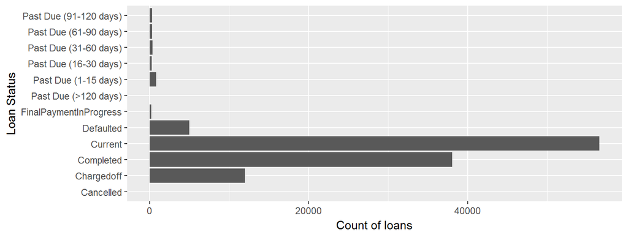

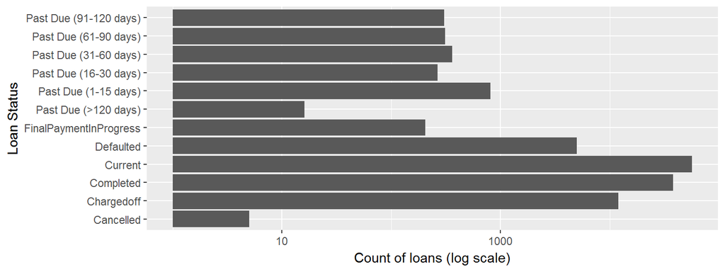

To make it easier to visualize good loans from bad loans, we convert all loans that are past due for more than 30 days, Defaulted and Chargedoff loans as **‘Bad loans’**. Count of Loan Status are shown in actual and log10 scale.

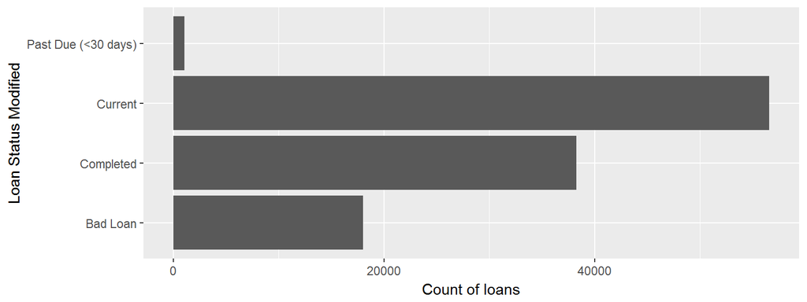

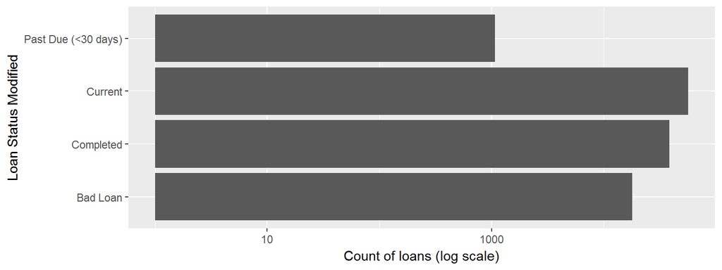

**Explore Prosper Score.** This score is built using Prosper historical data.

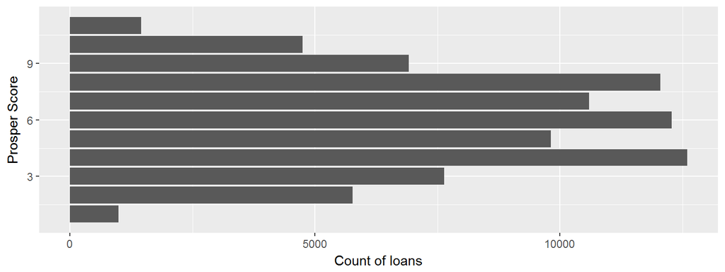

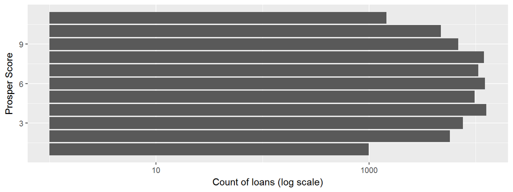

ProsperScore is supposed to have values ranging from 1-10. But it also seem to have 11.

```
##
##     1     2     3     4     5     6     7     8     9    10    11
##   992  5766  7642 12595  9813 12278 10597 12053  6911  4750  1456
```

**Explore Term values:**

```
##   Loan Term Freq count of Loan Term
## 1        12                    1614
## 2        36                   87773
## 3        60                   24545
```

There are only 3 terms 12, 36, and 60, and the most common seems to be 36.

**Explore Income Range:**

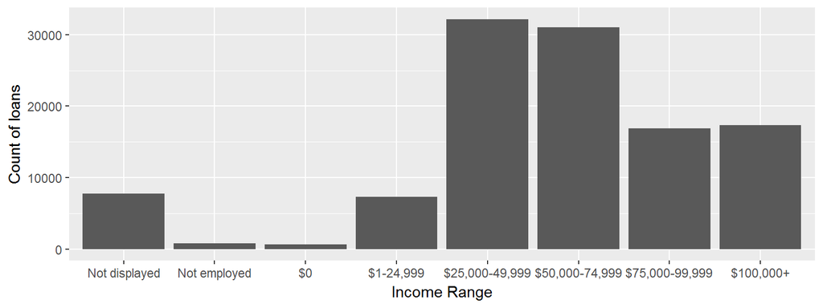

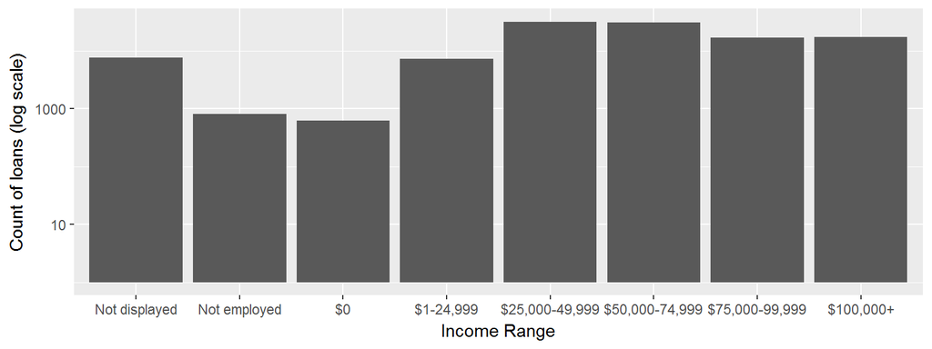

Most frequent Income Range is $25k - 75k,

**Explore Total number of Inquiries in past 6 months:**

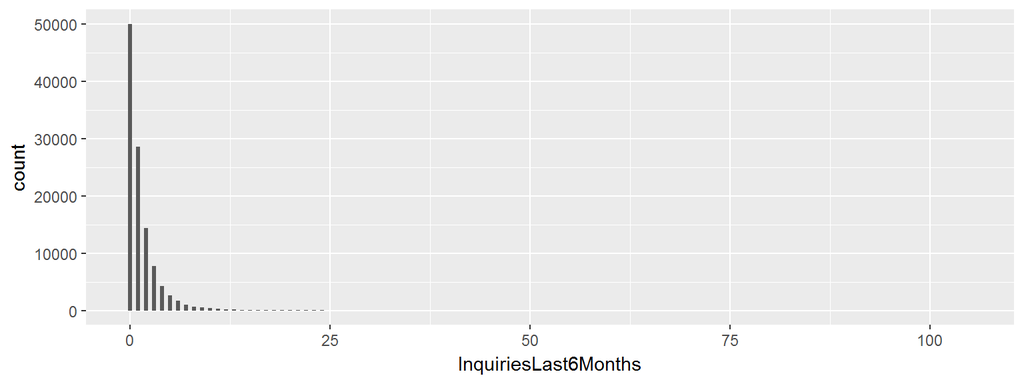

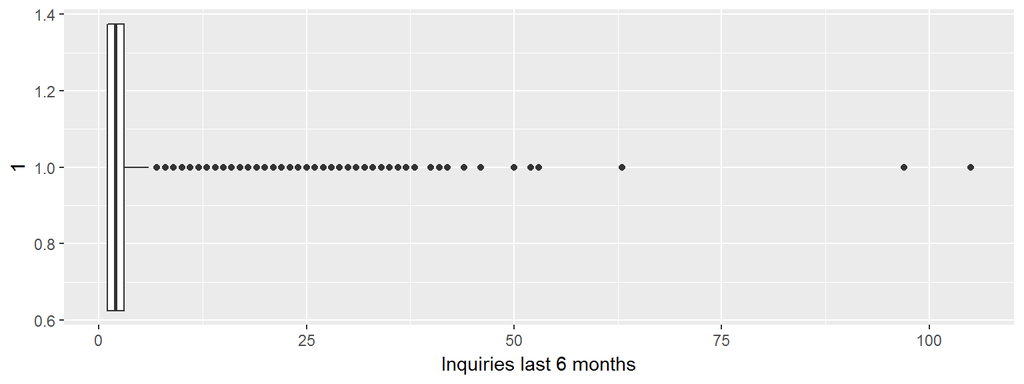

There seems to be outliers that are large distance away from the IQR range of data. We try to limit the upper range at 30.

Check how frequency for each InquiriesLast6Months value:

```
##
##     0     1     2     3     4     5     6     7     8     9    10    11
## 50004 28619 14432  7697  4297  2610  1664  1014   696   508   372   275
##    12    13    14    15    16    17    18    19    20    21    22    23
##   206   163   128    98    79    64    53    33    30    40    22    18
##    24    25    26    27    28    29    30    31    32    33    34    35
##    16    14    14     8     8     6     4    10     4     2     4     4
##    36    37    38    40    41    42    44    46    50    52    53    63
##     1     3     2     3     1     1     2     1     1     1     1     1
##    97   105
##     1     1
```

Majority of records have anywhere between 0-2 inquiries in last 6 months. To make those more visible, lets focus on only records with 0-4 inquiries in last 6 months.

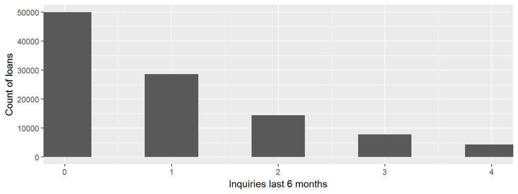

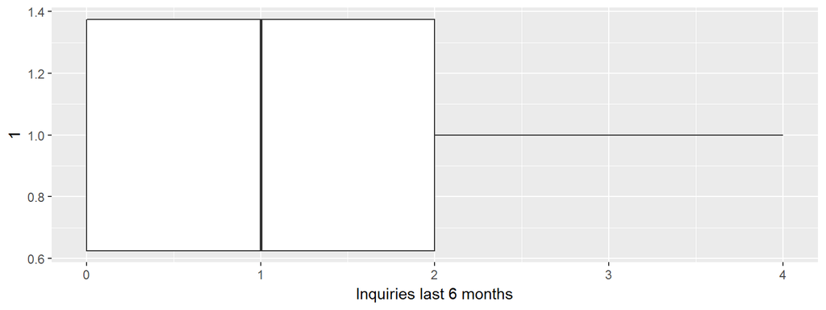

Most inquiries in last 6 months tend to between 0 and 2.

**Explore Debt to Income Ratio:**

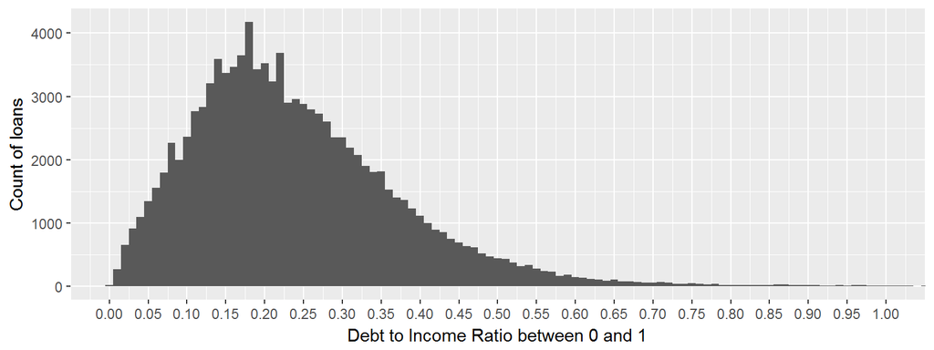

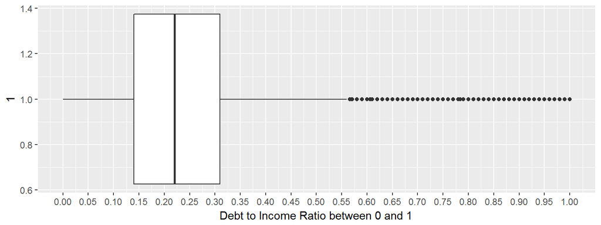

**Explore Credit Scores (Lower Range):**

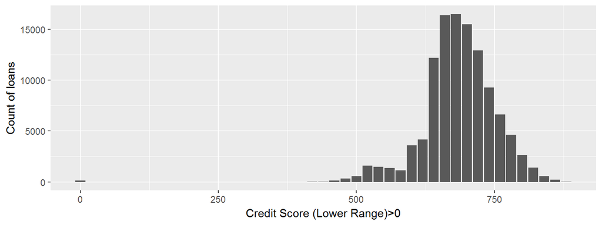

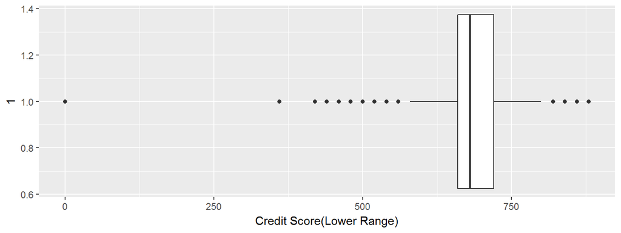

There seems to be loans without or very low credit scores, Credit Score. So we only look at those with credit scores larger than 500.

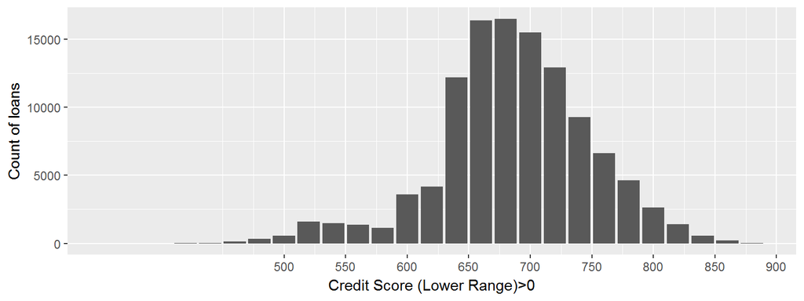

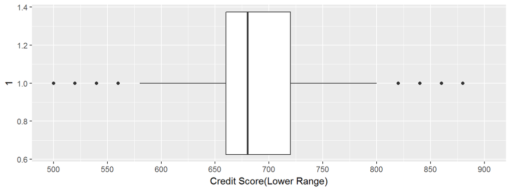

Most Credit Scores fall between 650 and 750.

# Univariate Analysis

### What is the structure of your dataset?

There are 113937 observations and 81 variables. Only 15 variables out of the original 81 are considered of interest for this analysis.

### What is/are the main feature(s) of interest in your dataset?

The main features of interest are as follows: “LoanStatus”, “Term”,“BorrowerAPR”, “CreditScoreRangeLower”, “ProsperScore”, “IncomeRange”, “TotalInquiries”,“DelinquenciesLast7Years”, “DebtToIncomeRatio”

### What other features in the dataset do you think will help support your investigation into your feature(s) of interest?

Other features that might help are: “BorrowerAPR”, “ProsperRating..Alpha.”, “EmploymentStatus”, “EmploymentStatusDuration”, “IsBorrowerHomeowner”, etc.

### Did you create any new variables from existing variables in the dataset?

Yes. I created LoanStatus_mod with consolidated bad-loan values.

### Of the features you investigated, were there any unusual distributions? Did you perform any operations on the data to tidy, adjust, or change the form of the data? If so, why did you do this?

Removed LoanStatus=“Cancelled”. The objective of this analysis is to study what differentiates good loan from bad loan. If the loan was cancelled, it did not contribute to the objective.

Reordered the levels for IncomeRange to make them appear in the plots in desired order.

# Bivariate Plots Section

**Study the relationship between Loan Status and Prosper Score:**

Histograms of Prospect Scores by Loan Status

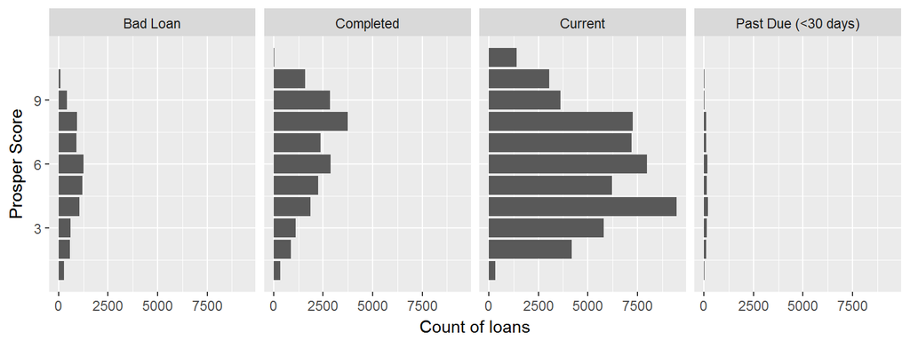

Bad Loan have Prosper Score concentrated towards the middle of the score range. Whereas Completed loans are concentrated at the higher range of Prosper Score.

Next is proportions of Loan Statuses for each Prosper Score bucket.

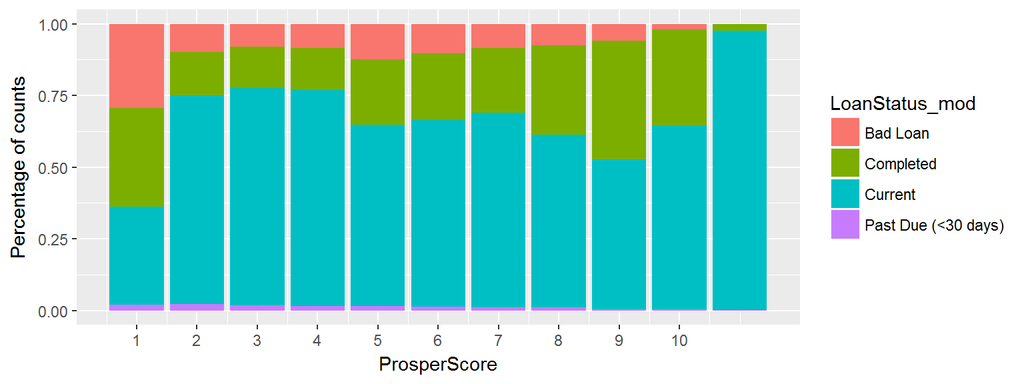

Loans with higher Prosper-score seems to have smaller proportion of bad loans, compared to those with lower scores.

**Explore relationship between Loan Status and Credit-Score:**

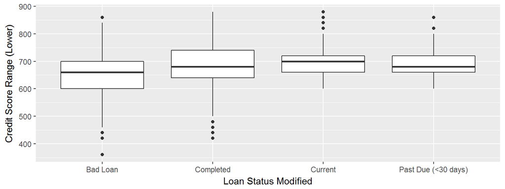

IQR range of Credit Scores for Bad Loans are lower compared to that of other Loan Statuses.

**Explore relationship between Loan Status and Current Delinquencies:**

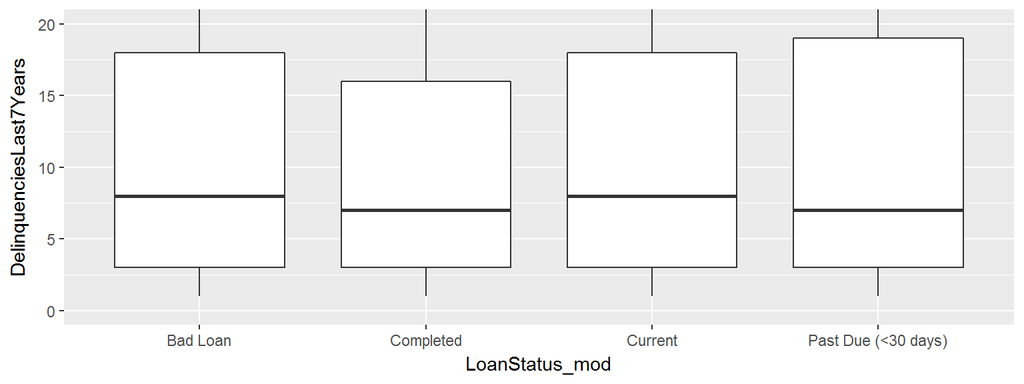

Number of Delinquencies in past 7 years does not seem to determine if the loan will be ‘bad’.

**Explore relationship between Inquiries in last 6 months and Debt to income ratio:**

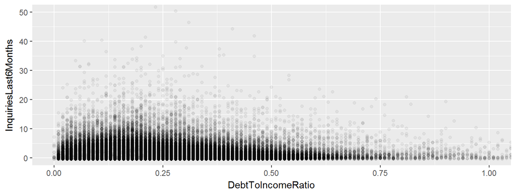

Overall, there doesn’t seem to be any relationship between Inquiries in last 6 months and Debt to income ratio

**Explore relationship between Income Range and Loan Status:**

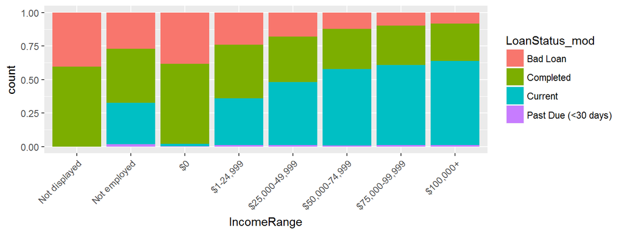

Loans with higher Income Range have smaller rate of Bad-Loans.

Next, we study the same relationship but without ‘Current’ loan status.

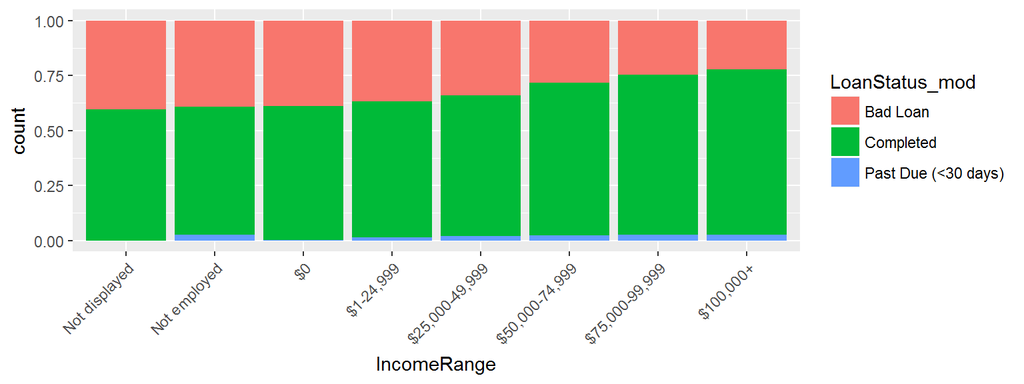

After excluding ‘current’ loan status, for income range ‘$100,000+’, about 25% are classified as Bad Loan. Comparing that to income range ‘$1-$25,000’, only about 35% of loans are classified as Bad loans.

**Explore relationship between Income Range and Debt to Income Ratio:**

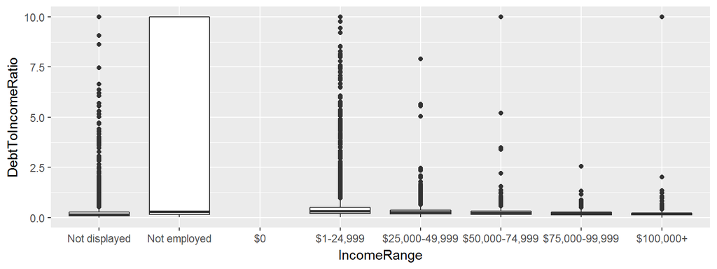

Most Debt to income ratio values are concentrated <1. So we zoom-in:

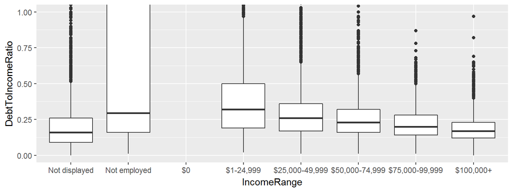

Loans with low income have debt to income ratio more spread out (with some exceeding 10.0). Whereas, Loans with higher income consistently have very low debt to income ratio.

**Explore relationships between LoanStatus and Debt to Income Ratio:**

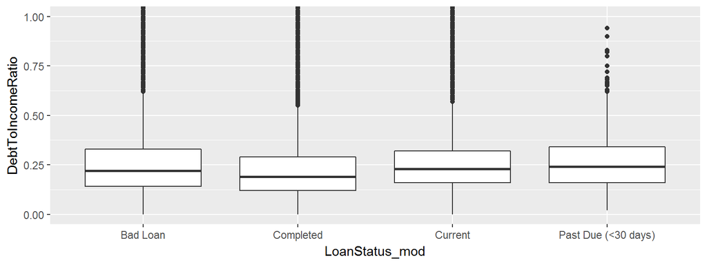

Debt to Income ratio does not vary a lot for different values of Loan Status. This is surprising because I expected the Bad Loans to have higher Debt to Income ratio.

**Pairwise graphs of variables among variables that are not of main interest:**

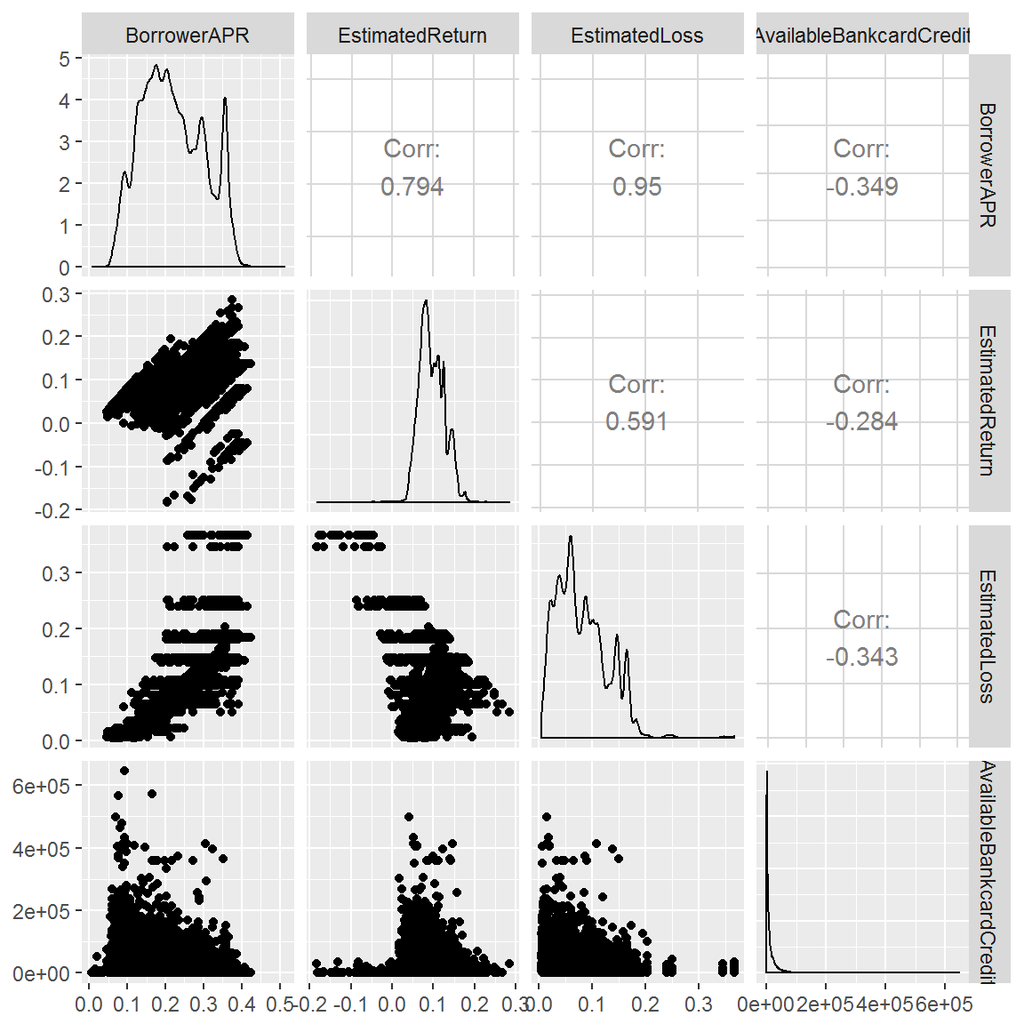

# Bivariate Analysis

### Talk about some of the relationships you observed in this part of the investigation. How did the feature(s) of interest vary with other features in the dataset?

Prosper Score for bad loans are concentrated more towards middle of the score range.

Credit score range for Bad loans (600-700) is lower than compared to completed loans (650-750).

Number of Delinquencies in tha pst 7 years do not seem to determine the loan status.

### Did you observe any interesting relationships between the other features (not the main feature(s) of interest)?

Borrower APR has positive relationship with Estimated Return, and with Estimated Loss.

### What was the strongest relationship you found?

The strongest relationship is that of Borrower APR against Estimated Return and Estimated Loss.

# Multivariate Plots Section

**Explore relationship between ProsperScore and Loan Status, grouped by credit score ranges:**

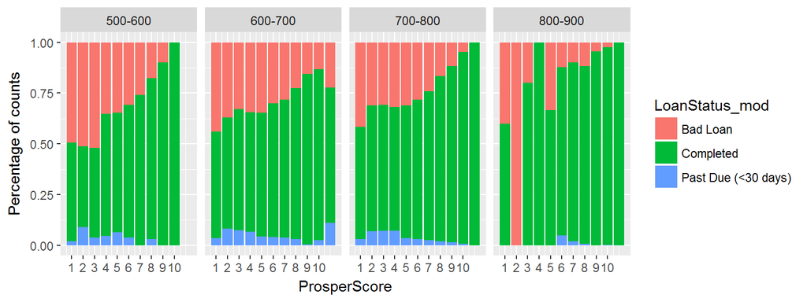

Credit scores 800 to 900 seem to have very less proportion of Bad loans for higher Prosper Scores. But for lower Prosper scores in the same credit range, the proportion of Bad loans are comparable to other Credit Score ranges. This tells us that just looking at the Credit Score might not be enough to determine if the loan will be good or bad.

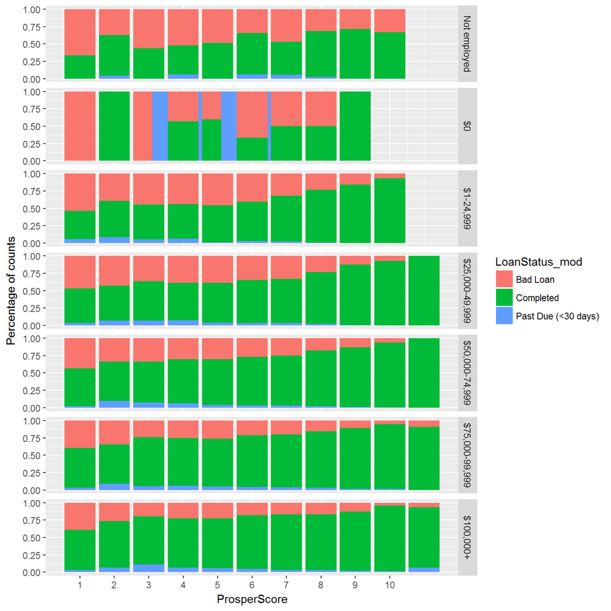

Higher Income ranges and higher Prosper Scores have less proportion of Bad Loans, compared to lower Income Ranges and Lower Prosper Scores.

**Explore relationship between Credit Score and mean Income Ranges, for each Loan Status type:**

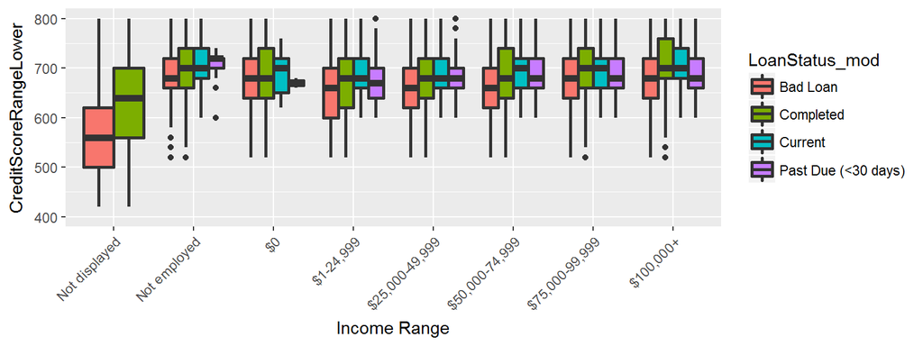

In general, credit scores for people with bad loans are lower compared to that for other groups. Surprisingly, overall credit scores for unemployed people is fairly high. For them, mean credit score do not seem to be good indicator their Loan Status.

Also, for employed people, credit score IQR range for bad loans and “Past Due (<30 Days)” seems to be lower than completed and current loans. This might indicate that for higher income-range group, it is more likey for people with lower credit scored to default on a loan.

So, for employed people, Income range and mean Credit Score seems to be good indicator of Loan Status.

**Explore relationships of Credit Scores, Income Range, and InquiriesLast6Months to Loan Status:**

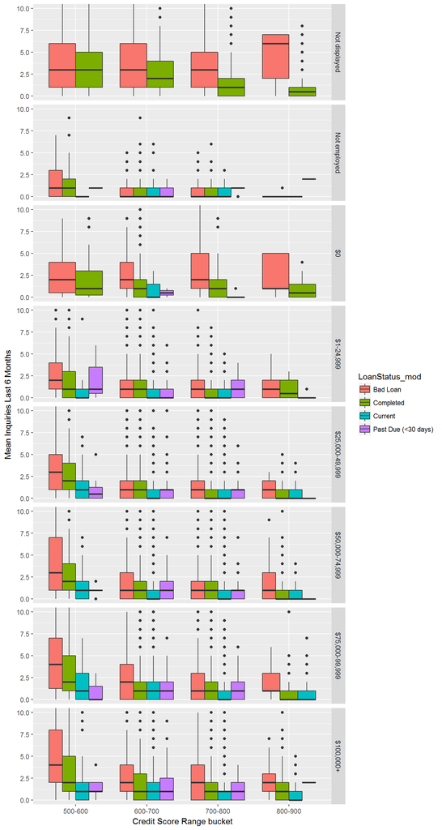

We can see that Bad Loans have slightly higher number of Inquiries in Last 6 Months for all Credit score range buckets and Income Ranges. Bad Loans in lower credit score range (500-600) and those in high range (800-900) seem to have the most variation in terms of number of Inquiries in Last 6 Months.

For lower Credit Score Range (500-600), completed loans have more Inquiries in Last 6 Months compared to Current loans. This might be because of the fact that completed loans includes past loans where investors were more willing to take larger risks (and therefore reaped larger rewards). But the investors for current loans are less willing to take risks (especially for people with lower credit scores). Therefore, we see them investing only on those loans with lower number of Inquiries.

**Study relationship between Income Range and Loan Status, by Income-Verifiable:**

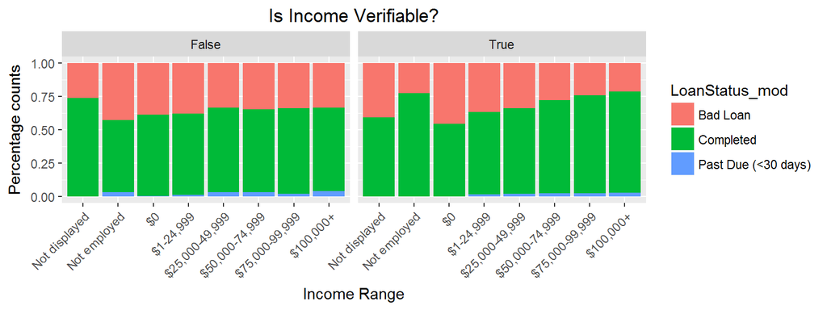

Non-verifiable Income group seems to have equal percentage of Bad Loans for all income ranges. Therefore, for Non-verifiable group, Income Range does not seem to be good inidcator of Loan Status.

**Explore relationship between Income Ranges and Debt to income Ratio, for each Loan Status type:**

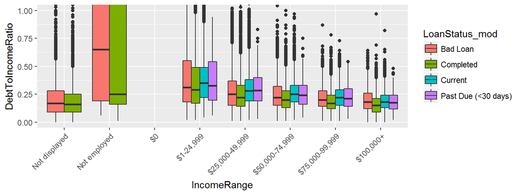

For each Income Range, Bad Loans have slightly lower Debt to Income ratio compared to Current loans, and slightly higher Debt to Income ratio compared to Completed loans. This is counterintuitive because one would expect the Bad Loans to have higher Debt to Income ratio than any other categories.

**Explore relationship between Debt to income Ratio and Inquiries in last 6 months, for each Loan Status type:**

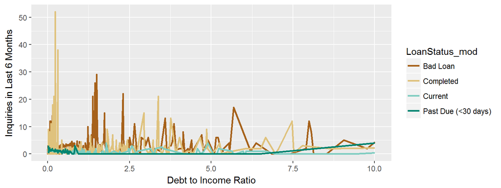

Looking at the mean Inquiries in Last 6 Months for different levels of Debt to Income Ratio, it is hard to read the chart because there is too much fluctuation over a short range.

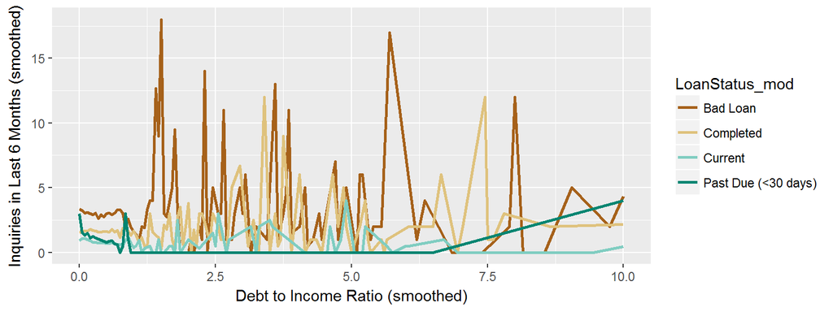

So, we smooth the chart by grouping Debt to Income ratio into increments of .5, and taking the mean of InquiriesLast6Months. The smoothed plot shows that Bad Loans have higher Inquiries in past 6 months compared to any other Loan Types.

In the lower range of DebtToIncomeRatio (0-2.5), it is interesting to see than Bad Loans deviate from Good Loans by a huge margin in terms of Inquiries in Last 6 Months. For DebtToIncomeRatio above 2.5, Loan Status values do not seem deviate a lot from each other.

Next, we attempt to facet the graph by Income Range:

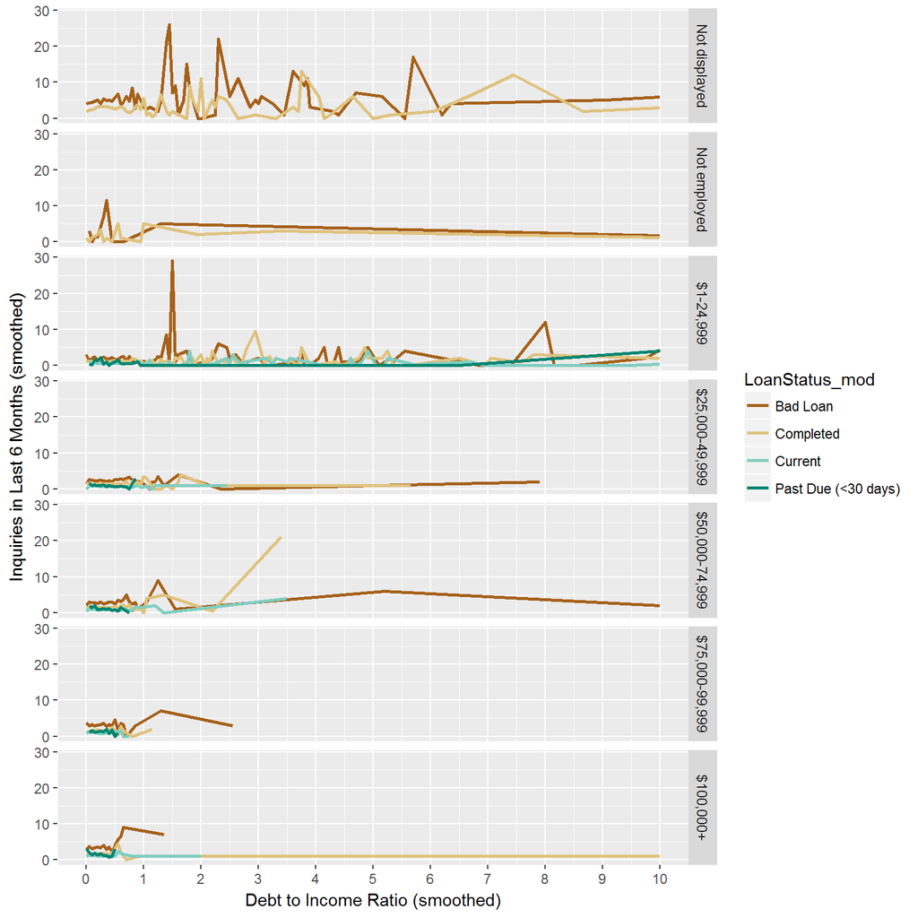

In general # of Inquiries are higher for Bad Loans compared to other Loan Statuses, for all income Ranges and Debt to Income ratio ranges.

For loans with Income Range of $1k to $25k, Not employed and Not displayed, # of inquiries are significantly higher for Bad Loans compared to Completed Loans. There is a huge peak at 1.5.

For Income range $25k or higher, # of inquiries are similar for all loan statuses.

# Multivariate Analysis

### Talk about some of the relationships you observed in this part of the investigation. Were there features that strengthened each other in terms of looking at your feature(s) of interest?

Loan Status (whether a loan will be Defaulted or not) seems to tbe highly related to Prosper Score, Credit Score, Income Ranges and Inquiries within last 6 months.

Income Range and Credit Score strengthened each other. Debt to Income Ratio and Inquiries within last 6 months also strengthened each other.

### Were there any interesting or surprising interactions between features?

### OPTIONAL: Did you create any models with your dataset? Discuss the strengths and limitations of your model.

I was expecting that the loans with higher Debt to Income Ratio will have more instances of Bad Debt. But that did not seem to be the case.

For unemployed people, mean credit score do not seem to be good indicator their Loan Status. But for employed poeple, it seems to be good indicator.

# Final Plots and Summary

### Plot One

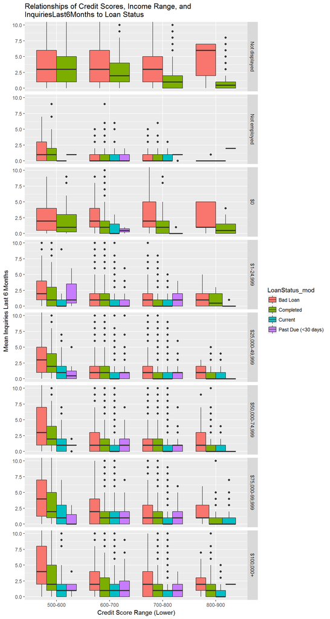

### Description One

This plot shows how Credit Scores, Income Range, and InquiriesLast6Months relates to Loan Status. Bad Loans have higher Number of Inquiries compared to the good ones, especially at lower Credit Score ranges. As the Credit Score increases, the difference becomes less and less obvious.

Completed loans have lower # of Inquiries than Bad Loans, but higher than Current ones (especially for lower Credit Score range). This might indicate that investors for more recent loans are less likely to invest in loans with higher number of inquiries and low credit scores.

### Plot Two

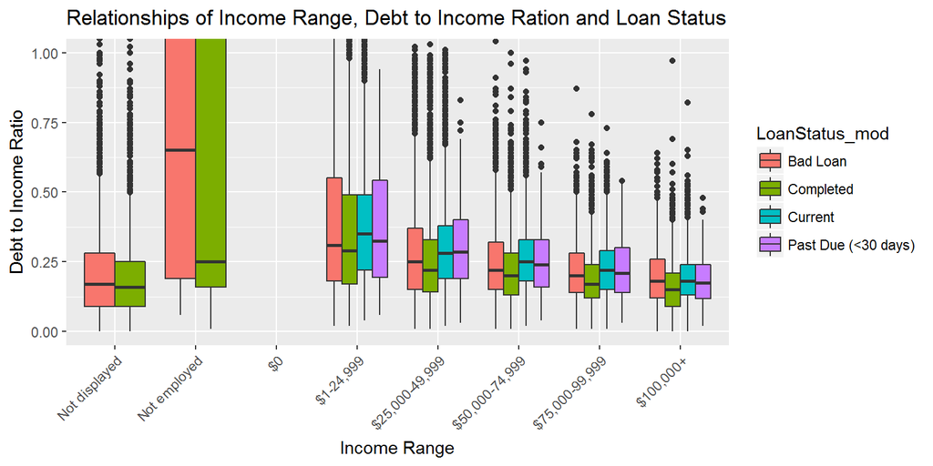

### Description Two

This plot shows that Debt to Income Ratio is not really a good indicator of Loan Status. This shows that people with higher debt are not necessarily more likely to default on their loans.

### Plot Three

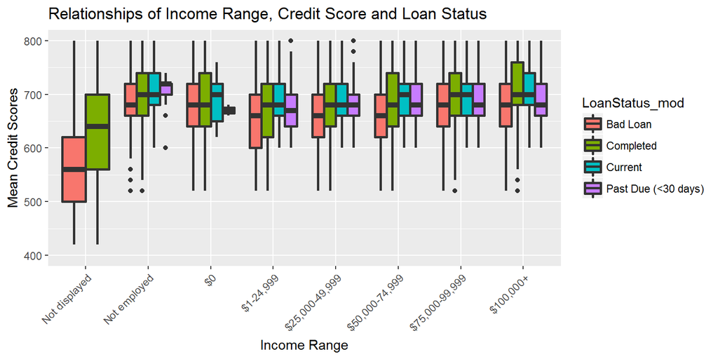

### Description Three

This plot shows that Income Range and Credit Scores are good indicator of Loan Status, but only for employed individuals.

Individuals with lower income seem to have lower Credit Scores in general, and among them, the individuals with bad loans seem to have lower credit scores than the completed/current loans.

Surprisingly, unemployed people have higher credit scores overall than employed people. This might be because investors are only comfortable lending to unemployed people if they have high credit scores.

# Reflection

This exploration was primarily focused on identifying attributes that distinguished between Completed loan and Bad Loans. Current loans were also studied in some cases.

Variables such as Prosper Score, Income Range, Credit Scores, and Inquiries made in Last 6 Months were all related to Loan Status in varying degrees. There variables are pretty good indicators to distinguish Bad loans from completed and current loans. It is also seen that perhaps the investors of current loans are more risk-averse than the investors for past completed & bad loans. Investors for current loans seem to be seeking out loans with higher credit scores and less number of Inquiries in Past 6 Months.

The main struggle I had when performing the analysis was selecting the best plot to use to represent features. There are many varieties of plots available, so it was lot of trial and error in determinng the best plot to convey information about certain group of features.

The main success I had was in identifying the features that differentiated bad loans from the good ones. I think I have a pretty good understanding of how different features are related to one another, and to the Loan Status. It was an interesting exercise because I could pretend that I was one of the investors, and that I was trying to study which loans should I invest in, and which I should avoid.

However, more work needs to be done to identify strategies to generate the most expected return for an investor. I believe valriables such as Borrower APR, Estimated Return, Listing Category, time since loan origination, and other attributes about the member can help investors maximize their returns.